# Chrysoperla carnea | Beneficial Insects for Cannabis | Plantsman

[figure not shown]

# Chrysoperla Carnea

$27.68 – $194.20

*Chrysoperla carnea* is an insect of the Chrysopidae family. The delicate looking adult feeds on nectar and pollen while the larvae of *C. carnea* is the active predator. The first three larvae instars are the voracious ones.

[output not shown]

## Description

Plantsman produces and markets biological products. Production is carried out using innovative techniques under controlled quality assurance standards for the mass production of insects. All products are tested to meet specification requirements before leaving the factory.

The success of biological pest control is affected by the crop’s initial pest population (upon application of the product), weather conditions and chemical residue present in the crop, among other possible aggravating factors.

Under no circumstance shall Plantsman be liable for the outcome of the implementation in the field, as it has no control over local conditions, the application method, or the possible improper treatment/storage of the product.

## Related products

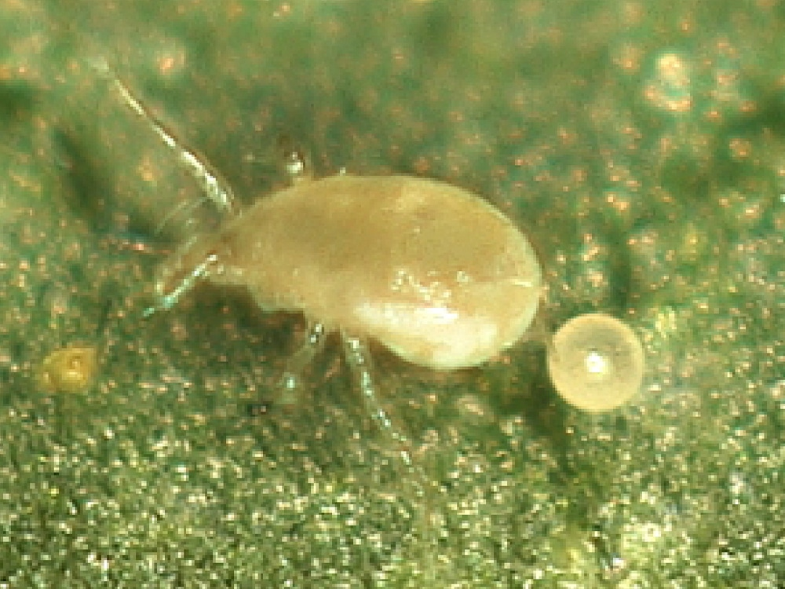

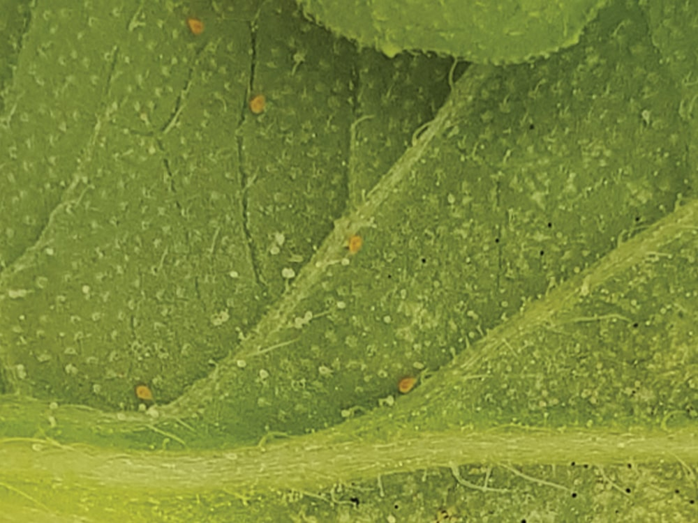

## Amblyseius Swirskii

  $86.46 – $719.73

[figure not shown]

## Venerate® CG

  $53.43 – $6,230.65

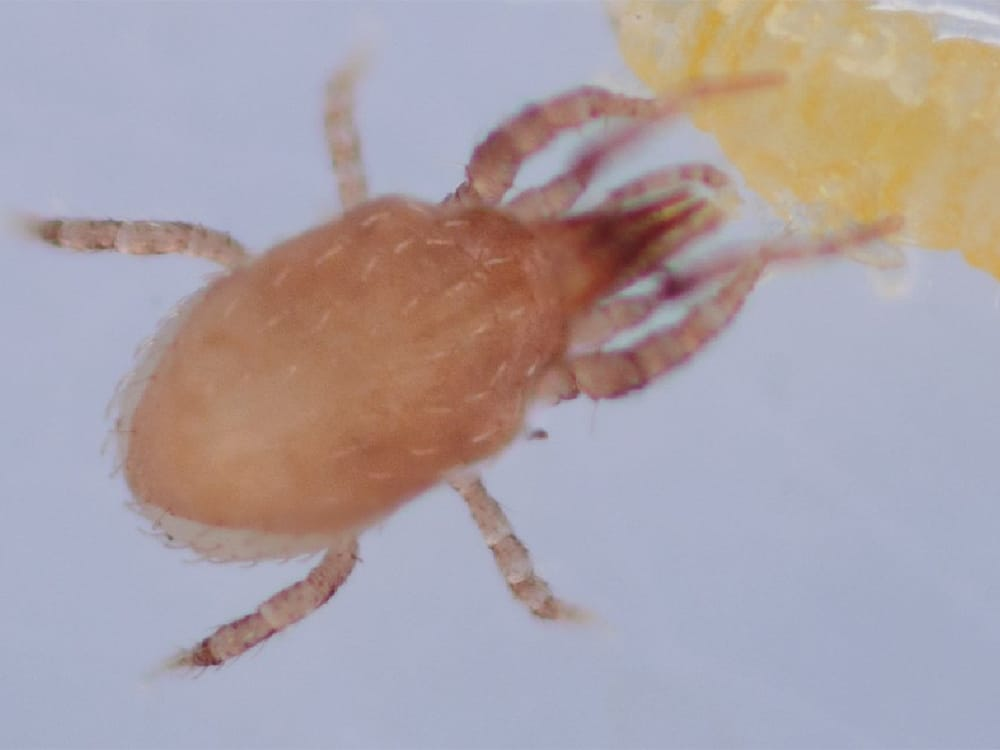

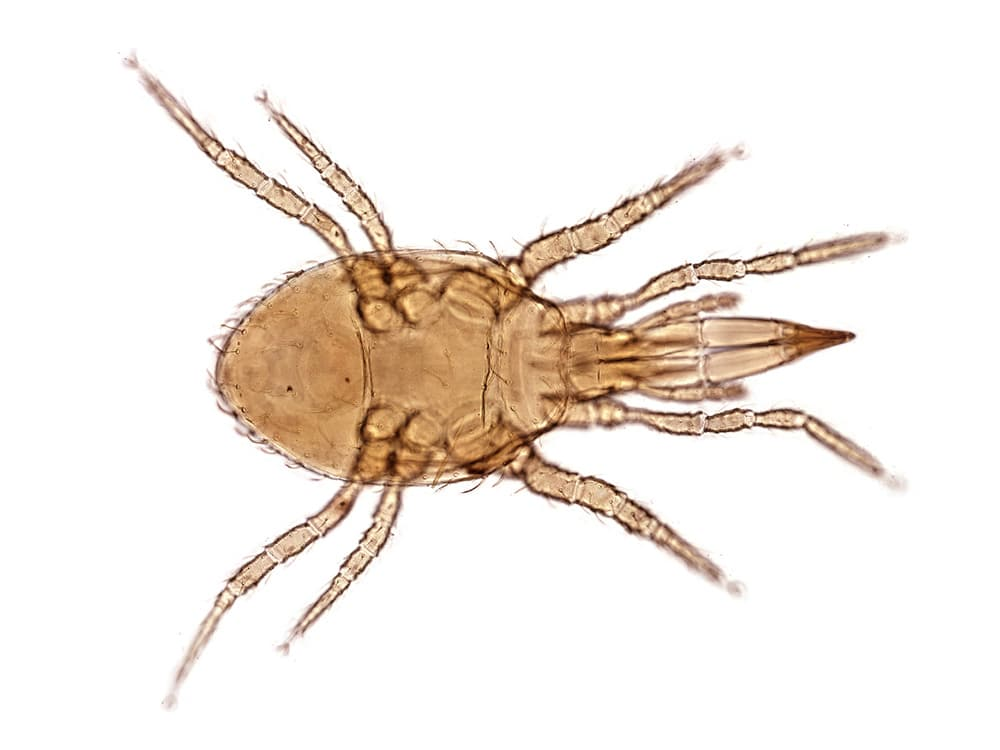